# TAO Image Classification

Transfer learning is the process of transferring learned features from one application to another. It is a commonly used training technique where you use a model trained on one task and re-train to use it on a different task.

Train Adapt Optimize (TAO) Toolkit is a simple and easy-to-use Python based AI toolkit for taking purpose-built AI models and customizing them with users' own data.

[figure not shown]

## Learning Objectives

In this notebook, you will learn how to leverage the simplicity and convenience of TAO to:

This notebook shows an example use case for classification using the Train Adapt Optimize (TAO) Toolkit.

1. Set up env variables and map drives
2. Installing the TAO Launcher
3. Prepare dataset and pretrained model
   1. Split the dataset into train/test/val
   2. Download pre-trained model
4. Provide training specfication
5. Run TAO training
6. Evaluate trained models
7. Prune trained models
8. Retrain pruned models
9. Testing the model
10. Visualize inferences
11. Export and Deploy!
    1. Int8 Optimization
    2. Generate TensorRT engine

## 0. Set up env variables and map drives

When using the purpose-built pretrained models from NGC, please make sure to set the `$KEY` environment variable to the key as mentioned in the model overview. Failing to do so, can lead to errors when trying to load them as pretrained models.

The following notebook requires the user to set an env variable called the `$LOCAL_PROJECT_DIR` as the path to the users workspace. Please note that the dataset to run this notebook is expected to reside in the `$LOCAL_PROJECT_DIR/data`, while the TAO experiment generated collaterals will be output to `$LOCAL_PROJECT_DIR/classification`. More information on how to set up the dataset and the supported steps in the TAO workflow are provided in the subsequent cells.

*Note: Please make sure to remove any stray artifacts/files from the `$USER_EXPERIMENT_DIR` or `$DATA_DOWNLOAD_DIR` paths as mentioned below, that may have been generated from previous experiments. Having checkpoint files etc may interfere with creating a training graph for a new experiment.*

*Note: This notebook currently is by default set up to run training using 1 GPU. To use more GPU's please update the env variable `$NUM_GPUS` accordingly*

```python
# Setting up env variables for cleaner command line commands.
import os

%env KEY=nvidia_tlt
%env NUM_GPUS=1
%env USER_EXPERIMENT_DIR=/workspace/tao-experiments/classification
%env DATA_DOWNLOAD_DIR=/workspace/tao-experiments/data

# Set this path if you don't run the notebook from the samples directory.
# %env NOTEBOOK_ROOT=~/tao-samples/classification

# Please define this local project directory that needs to be mapped to the TAO docker session.
# The dataset expected to be present in $LOCAL_PROJECT_DIR/data, while the results for the steps
# in this notebook will be stored at $LOCAL_PROJECT_DIR/classification
# !PLEASE MAKE SURE TO UPDATE THIS PATH!.
os.environ["LOCAL_PROJECT_DIR"] = '/home/ubuntu/cv_samples_v1.2.0/classification'

os.environ["LOCAL_DATA_DIR"] = os.path.join(
    os.getenv("LOCAL_PROJECT_DIR", os.getcwd()),
    "data"
)
os.environ["LOCAL_EXPERIMENT_DIR"] = os.path.join(
    os.getenv("LOCAL_PROJECT_DIR", os.getcwd()),
    "classification"
)

# The sample spec files are present in the same path as the downloaded samples.
os.environ["LOCAL_SPECS_DIR"] = os.path.join(
    os.getenv("NOTEBOOK_ROOT", os.getcwd()),
    "specs"
)
%env SPECS_DIR=/workspace/tao-experiments/classification/specs

# Showing list of specification files.
!ls -rlt $LOCAL_SPECS_DIR
```

```
env: KEY=nvidia_tlt
env: NUM_GPUS=1
env: USER_EXPERIMENT_DIR=/workspace/tao-experiments/classification
env: DATA_DOWNLOAD_DIR=/workspace/tao-experiments/data
env: SPECS_DIR=/workspace/tao-experiments/classification/specs
total 8
-rw-rw-r-- 1 ubuntu ubuntu 1272 Aug 24 23:51 classification_spec.cfg
-rw-rw-r-- 1 ubuntu ubuntu 1142 Aug 24 23:51 classification_retrain_spec.cfg
```

The cell below maps the project directory on your local host to a workspace directory in the TAO docker instance, so that the data and the results are mapped from outside to inside of the docker instance.

```python
# Mapping up the local directories to the TAO docker.
import json
import os
mounts_file = os.path.expanduser("~/.tao_mounts.json")

# Define the dictionary with the mapped drives
drive_map = {
    "Mounts": [
        # Mapping the data directory
        {
            "source": os.environ["LOCAL_PROJECT_DIR"],
            "destination": "/workspace/tao-experiments"
        },
        # Mapping the specs directory.
        {
            "source": os.environ["LOCAL_SPECS_DIR"],
            "destination": os.environ["SPECS_DIR"]
        },
    ],
    "DockerOptions":{
        "user": "{}:{}".format(os.getuid(), os.getgid())
    }
}

# Writing the mounts file.
with open(mounts_file, "w") as mfile:
    json.dump(drive_map, mfile, indent=4)
```

```python
!cat ~/.tao_mounts.json
```

```
{
    "Mounts": [
        {
            "source": "/home/ubuntu/cv_samples_v1.2.0/classification",
            "destination": "/workspace/tao-experiments"
        },
        {
            "source": "/home/ubuntu/cv_samples_v1.2.0/classification/specs",
            "destination": "/workspace/tao-experiments/classification/specs"
        }
    ],
    "DockerOptions": {
        "user": "1000:1000"
    }
}
```

## 1. Installing the TAO launcher

The TAO launcher is a python package distributed as a python wheel listed in the `nvidia-pyindex` python index. You may install the launcher by executing the following cell.

Please note that TAO Toolkit recommends users to run the TAO launcher in a virtual env with python 3.6.9. You may follow the instruction in this [page](https://virtualenvwrapper.readthedocs.io/en/latest/install.html) to set up a python virtual env using the `virtualenv` and `virtualenvwrapper` packages. Once you have setup virtualenvwrapper, please set the version of python to be used in the virtual env by using the `VIRTUALENVWRAPPER_PYTHON` variable. You may do so by running

```
export VIRTUALENVWRAPPER_PYTHON=/path/to/bin/python3.x
```

where x >= 6 and <= 8

We recommend performing this step first and then launching the notebook from the virtual environment. In addition to installing TAO python package, please make sure of the following software requirements:

- python >=3.6.9 < 3.8.x
- docker-ce > 19.03.5
- docker-API 1.40
- nvidia-container-toolkit > 1.3.0-1
- nvidia-container-runtime > 3.4.0-1
- nvidia-docker2 > 2.5.0-1
- nvidia-driver > 455+

Once you have installed the pre-requisites, please log in to the docker registry nvcr.io by following the command below

```
docker login nvcr.io
```

You will be trigerred to enter a username and password. The username is `$oauthtoken` and the password is the API key generated from `ngc.nvidia.com`. Please follow the instructions in the [NGC setup guide](https://docs.nvidia.com/ngc/ngc-overview/index.html#generating-api-key) to generate your own API key.

Please note that TAO Toolkit recommends users to run the TAO launcher in a virtual env with python 3.6.9. You may follow the instruction in this [page](https://virtualenvwrapper.readthedocs.io/en/latest/install.html) to set up a python virtual env using the `virtualenv` and `virtualenvwrapper` packages. Once you have setup virtualenvwrapper, please set the version of python to be used in the virtual env by using the `VIRTUALENVWRAPPER_PYTHON` variable. You may do so by running

```python
# SKIP this cell IF you have already installed the TAO launcher.
!pip3 install nvidia-pyindex
!pip3 install nvidia-tao
```

```python
# View the versions of the TAO launcher
!tao info
```

```
Configuration of the TAO Toolkit Instance
dockers: ['nvidia/tao/tao-toolkit-tf', 'nvidia/tao/tao-toolkit-pyt', 'nvidia/tao/tao-toolkit-lm']
format_version: 1.0
toolkit_version: 3.21.08
published_date: 08/17/2021
```

## 2. Prepare datasets and pre-trained model

```python
# Check that file is present
import os
DATA_DIR = os.environ.get('LOCAL_DATA_DIR')
# print(DATA_DIR)
# if not os.path.isfile(os.path.join(DATA_DIR , 'VOCtrainval_11-May-2012.tar')):
#     print('tar file for dataset not found. Please download.')
# else:
#     print('Found dataset.')
```

```python
# unpack
# !tar -xvf $LOCAL_DATA_DIR/VOCtrainval_11-May-2012.tar -C $LOCAL_DATA_DIR
```

```python
# verify
# !ls $LOCAL_DATA_DIR/VOCdevkit/VOC2012
```

### A. Split the dataset into train/val/test

```python
# # install pip requirements
# !pip3 install tqdm
# !pip3 install matplotlib==3.3.3
```

```python
from os.path import join as join_path
import os
import glob
import re
import shutil

DATA_DIR=os.environ.get('LOCAL_DATA_DIR')
source_dir = join_path(DATA_DIR, "VOCdevkit/VOC2012")
target_dir = join_path(DATA_DIR, "formatted")


suffix = '_trainval.txt'
classes_dir = join_path(source_dir, "ImageSets", "Main")
images_dir = join_path(source_dir, "JPEGImages")
classes_files = glob.glob(classes_dir+"/*"+suffix)
for file in classes_files:
    # get the filename and make output class folder
    classname = os.path.basename(file)
    if classname.endswith(suffix):
        classname = classname[:-len(suffix)]
        target_dir_path = join_path(target_dir, classname)
        if not os.path.exists(target_dir_path):
            os.makedirs(target_dir_path)
    else:
        continue
    print(classname)


    with open(file) as f:
        content = f.readlines()


    for line in content:
        tokens = re.split('\s+', line)
        if tokens[1] == '1':
            # copy this image into target dir_path
            target_file_path = join_path(target_dir_path, tokens[0] + '.jpg')
            src_file_path = join_path(images_dir, tokens[0] + '.jpg')
            shutil.copyfile(src_file_path, target_file_path)
```

```python
import os
import glob
import shutil
from random import shuffle
from tqdm import tqdm

DATA_DIR=os.environ.get('LOCAL_DATA_DIR')
SOURCE_DIR=os.path.join(DATA_DIR, 'formatted')
TARGET_DIR=os.path.join(DATA_DIR,'split')
# list dir
print(os.walk(SOURCE_DIR))
dir_list = next(os.walk(SOURCE_DIR))[1]
# for each dir, create a new dir in split
for dir_i in tqdm(dir_list):
        newdir_train = os.path.join(TARGET_DIR, 'train', dir_i)
        newdir_val = os.path.join(TARGET_DIR, 'val', dir_i)
        newdir_test = os.path.join(TARGET_DIR, 'test', dir_i)

        if not os.path.exists(newdir_train):
                os.makedirs(newdir_train)
        if not os.path.exists(newdir_val):
                os.makedirs(newdir_val)
        if not os.path.exists(newdir_test):
                os.makedirs(newdir_test)

        img_list = glob.glob(os.path.join(SOURCE_DIR, dir_i, '*.jpg'))
        # shuffle data
        shuffle(img_list)

        for j in range(int(len(img_list)*0.7)):
                shutil.copy2(img_list[j], os.path.join(TARGET_DIR, 'train', dir_i))

        for j in range(int(len(img_list)*0.7), int(len(img_list)*0.8)):
                shutil.copy2(img_list[j], os.path.join(TARGET_DIR, 'val', dir_i))

        for j in range(int(len(img_list)*0.8), len(img_list)):
                shutil.copy2(img_list[j], os.path.join(TARGET_DIR, 'test', dir_i))

print('Done splitting dataset.')
```

```
<generator object walk at 0x7f1be0073830>
```

```
Done splitting dataset.
```

```python
!ls $LOCAL_DATA_DIR/split/test/
```

```
alexandrum  nonalexandrum
```

### B. Download pretrained models

We will use NGC CLI to get the pre-trained models. For more details, go to ngc.nvidia.com and click the SETUP on the navigation bar.

```python
# Installing NGC CLI on the local machine.
## Download and install
%env CLI=ngccli_cat_linux.zip
!mkdir -p $LOCAL_PROJECT_DIR/ngccli

# Remove any previously existing CLI installations
!rm -rf $LOCAL_PROJECT_DIR/ngccli/*
!wget "https://ngc.nvidia.com/downloads/$CLI" -P $LOCAL_PROJECT_DIR/ngccli
!unzip -u "$LOCAL_PROJECT_DIR/ngccli/$CLI" -d $LOCAL_PROJECT_DIR/ngccli/
!rm $LOCAL_PROJECT_DIR/ngccli/*.zip
os.environ["PATH"]="{}/ngccli:{}".format(os.getenv("LOCAL_PROJECT_DIR", ""), os.getenv("PATH", ""))
```

```python
!ngc registry model list nvidia/tao/pretrained_classification:*
```

```python
!mkdir -p $LOCAL_EXPERIMENT_DIR/pretrained_resnet18/
```

```python
# Pull pretrained model from NGC
!ngc registry model download-version nvidia/tao/pretrained_classification:resnet18 --dest $LOCAL_EXPERIMENT_DIR/pretrained_resnet18
```

```python
print("Check that model is downloaded into dir.")
!ls -l $LOCAL_EXPERIMENT_DIR/pretrained_resnet18/pretrained_classification_vresnet18
```

## 3. Provide training specfication

- Training dataset
- Validation dataset
- Pre-trained models
- Other training (hyper-)parameters such as batch size, number of epochs, learning rate etc.

```python
!cat $LOCAL_SPECS_DIR/classification_spec.cfg
```

[output not shown]

## 4. Run TAO training

- Provide the sample spec file and the output directory location for models

```python
!tao classification train -e $SPECS_DIR/classification_spec.cfg -r $USER_EXPERIMENT_DIR/output -k $KEY --use_amp > out_resnet18_train_amp16.log
```

```
2021-11-28 08:57:30,365 [INFO] root: Registry: ['nvcr.io']
2021-11-28 08:57:38,757 [INFO] tlt.components.docker_handler.docker_handler: Stopping container.
```

```python
print("To run this training in data parallelism using multiple GPU's, please uncomment the line below and "
      "update the --gpus parameter to the number of GPU's you wish to use.")
# !tao classification train -e $SPECS_DIR/classification_spec.cfg \
#                       -r $USER_EXPERIMENT_DIR/output \
#                       -k $KEY --gpus 2
```

```
To run this training in data parallelism using multiple GPU's, please uncomment the line below and update the --gpus parameter to the number of GPU's you wish to use.
```

```python
print("""
      To run this training in model parallelism using multiple GPU's, please uncomment the line below and update the
      --gpus parameter to the number of GPU's you wish to use. Also add related parameters in training_config to
      enable model parallelism. E.g.,

             model_parallelism: 50
             model_parallelism: 50

""")

#!tao classification train -e $SPECS_DIR/classification_spec.cfg \
#                       -r $USER_EXPERIMENT_DIR/output \
#                       -k $KEY --gpus 2 \
#                       -np 1
```

```
      To run this training in model parallelism using multiple GPU's, please uncomment the line below and update the
      --gpus parameter to the number of GPU's you wish to use. Also add related parameters in training_config to
      enable model parallelism. E.g.,

             model_parallelism: 50
             model_parallelism: 50
```

```python
print("To resume from a checkpoint, use --init_epoch along with your checkpoint configured in the spec file.")
print("Please make sure that the model_path in the spec file is now updated to the '.tlt' file of the corresponding"
      "epoch you wish to resume from. You may choose from the files found under, '$USER_EXPERIMENT_DIR/output/weights' folder.")
# !tao classification train -e $SPECS_DIR/classification_spec.cfg \
#                        -r $USER_EXPERIMENT_DIR/output \
#                        -k $KEY --gpus 2 \
#                        --init_epoch N
```

```
To resume from a checkpoint, use --init_epoch along with your checkpoint configured in the spec file.
Please make sure that the model_path in the spec file is now updated to the '.tlt' file of the correspondingepoch you wish to resume from. You may choose from the files found under, '$USER_EXPERIMENT_DIR/output/weights' folder.
```

## 5. Evaluate trained models

In this step, we assume that the training is complete and the model from the final epoch (`resnet_080.tlt`) is available. If you would like to run evaluation on an earlier model, please edit the spec file at `$SPECS_DIR/classification_spec.cfg` to point to the intended model.

```python
!tao classification evaluate -e $SPECS_DIR/classification_spec.cfg -k $KEY
```

[output not shown]

[output cut: 210 more lines]

```
2021-11-28 09:02:22,315 [INFO] __main__: Calculating per-class P/R and confusion matrix. It may take a while...
Confusion Matrix
[[508   5]
 [  1 203]]
Classification Report
               precision    recall  f1-score   support

   alexandrum       1.00      0.99      0.99       513
nonalexandrum       0.98      1.00      0.99       204

    micro avg       0.99      0.99      0.99       717
    macro avg       0.99      0.99      0.99       717
 weighted avg       0.99      0.99      0.99       717

2021-11-28 09:03:31,280 [INFO] tlt.components.docker_handler.docker_handler: Stopping container.
```

## 6. Prune trained models

- Specify pre-trained model
- Equalization criterion
- Threshold for pruning
- Exclude prediction layer that you don't want pruned (e.g. predictions)

```python
# Defining the checkpoint epoch number of the model to be used for the pruning.
# This should be lesser than the number of epochs training has been run for, incase training was interrupted earlier.
# By default, the default final model is at epoch 080.
%env EPOCH=046
!mkdir -p $LOCAL_EXPERIMENT_DIR/output/resnet_pruned
!tao classification prune -m $USER_EXPERIMENT_DIR/output/weights/resnet_$EPOCH.tlt \
           -o $USER_EXPERIMENT_DIR/output/resnet_pruned/resnet18_nopool_bn_pruned.tlt \
           -eq union \
           -pth 0.6 \
           -k $KEY
```

```
env: EPOCH=046
2021-11-28 09:03:55,899 [INFO] root: Registry: ['nvcr.io']
Matplotlib created a temporary config/cache directory at /tmp/matplotlib-2sihbv9n because the default path (/.config/matplotlib) is not a writable directory; it is highly recommended to set the MPLCONFIGDIR environment variable to a writable directory, in particular to speed up the import of Matplot…
WARNING:tensorflow:Deprecation warnings have been disabled. Set TF_ENABLE_DEPRECATION_WARNINGS=1 to re-enable them.
2021-11-28 09:04:05,603 [INFO] modulus.pruning.pruning: Exploring graph for retainable indices
2021-11-28 09:04:06,181 [INFO] modulus.pruning.pruning: Pruning model and appending pruned nodes to new graph
2021-11-28 09:04:22,664 [INFO] iva.common.magnet_prune: Pruning ratio (pruned model / original model): 0.8679345674488391
2021-11-28 09:04:24,241 [INFO] tlt.components.docker_handler.docker_handler: Stopping container.
```

```python
print('Pruned model:')
print('------------')
!ls -r1t $LOCAL_EXPERIMENT_DIR/output/resnet_pruned
```

```
Pruned model:
------------
resnet18_nopool_bn_pruned.tlt
```

## 7. Retrain pruned models

- Model needs to be re-trained to bring back accuracy after pruning
- Specify re-training specification

```python
!cat $LOCAL_SPECS_DIR/classification_retrain_spec.cfg
```

```
model_config {
  arch: "resnet",
  n_layers: 18
  use_batch_norm: true
  all_projections: true
  input_image_size: "3,224,224"
}
train_config {
  train_dataset_path: "/workspace/tao-experiments/data/split/train"
  val_dataset_path: "/workspace/tao-experiments/data/split/val"
  pretrained_model_path: "/workspace/tao-experiments/classification/output/resnet_pruned/resnet18_nopool_bn_pruned.tlt"
  optimizer {
    sgd {
    lr: 0.01
    decay: 0.0
    momentum: 0.9
    nesterov: False
  }
}
  batch_size_per_gpu: 64
  n_epochs: 80
  n_workers: 16
  preprocess_mode: "caffe"
  enable_random_crop: True
  enable_center_crop: True
  label_smoothing: 0.0
  mixup_alpha: 0.1
  # regularizer
  reg_config {
    type: "L2"
    scope: "Conv2D,Dense"
    weight_decay: 0.00005
  }

  # learning_rate
  lr_config {
    step {
      learning_rate: 0.006
      step_size: 10
      gamma: 0.1
    }
  }
}
eval_config {
  eval_dataset_path: "/workspace/tao-experiments/data/split/test"
  model_path: "/workspace/tao-experiments/classification/output_retrain/weights/resnet_080.tlt"
  top_k: 3
  batch_size: 256
  n_workers: 8
  enable_center_crop: True
}
```

```python
!tao classification train -e $SPECS_DIR/classification_retrain_spec.cfg \
                      -r $USER_EXPERIMENT_DIR/output_retrain \
                      -k $KEY --use_amp > out_resnet18_retrain_amp16.log
```

```
2021-11-28 09:05:00,925 [INFO] root: Registry: ['nvcr.io']
```

## 8. Testing the model!

In this step, we assume that the training is complete and the model from the final epoch (`resnet_080.tlt`) is available. If you would like to run evaluation on an earlier model, please edit the spec file at `$SPECS_DIR/classification_retrain_spec.cfg` to point to the intended model.

```python
!tao classification evaluate -e $SPECS_DIR/classification_retrain_spec.cfg -k $KEY
```

[output not shown]

[output cut: 210 more lines]

```
2021-11-28 09:37:01,043 [INFO] __main__: Calculating per-class P/R and confusion matrix. It may take a while...
Confusion Matrix
[[509   4]
 [  2 202]]
Classification Report
               precision    recall  f1-score   support

   alexandrum       1.00      0.99      0.99       513
nonalexandrum       0.98      0.99      0.99       204

    micro avg       0.99      0.99      0.99       717
    macro avg       0.99      0.99      0.99       717
 weighted avg       0.99      0.99      0.99       717

2021-11-28 09:38:09,765 [INFO] tlt.components.docker_handler.docker_handler: Stopping container.
```

## 9. Visualize Inferences

To see the output results of our model on test images, we can use the `tlt-infer` tool. Note that using models trained for higher epochs will usually result in better results. We'll run inference with the directory mode. You can also use the single image mode.

```python
# Defining the checkpoint epoch number to use for the subsequent steps.
# This should be lesser than the number of epochs training has been run for, incase training was interrupted earlier.
# By default, the default final model is at epoch 080.
%env EPOCH=046
```

```
env: EPOCH=046
```

```python
!tao classification inference -e $SPECS_DIR/classification_retrain_spec.cfg \
                          -m $USER_EXPERIMENT_DIR/output_retrain/weights/resnet_$EPOCH.tlt \
                          -k $KEY -b 32 -d $DATA_DOWNLOAD_DIR/split/test/nonalexandrum \
                          -cm $USER_EXPERIMENT_DIR/output_retrain/classmap.json
```

[output not shown]

[output cut: 189 more lines]

```
block_4b_relu (Activation)      (None, 512, 14, 14)  0           add_8[0][0]
__________________________________________________________________________________________________
avg_pool (AveragePooling2D)     (None, 512, 1, 1)    0           block_4b_relu[0][0]
__________________________________________________________________________________________________
flatten (Flatten)               (None, 512)          0           avg_pool[0][0]
__________________________________________________________________________________________________
predictions (Dense)             (None, 2)            1026        flatten[0][0]
==================================================================================================
Total params: 10,018,994
Trainable params: 9,958,562
Non-trainable params: 60,432
__________________________________________________________________________________________________
2021-11-28 09:44:53,562 [INFO] __main__: Processing /workspace/tao-experiments/data/split/test/nonalexandrum...
2021-11-28 09:45:16,649 [INFO] __main__: Inference complete. Result is saved at /workspace/tao-experiments/data/split/test/nonalexandrum/result.csv
2021-11-28 09:45:18,609 [INFO] tlt.components.docker_handler.docker_handler: Stopping container.
```

As explained in Getting Started Guide, this outputs a results.csv file in the same directory. We can use a simple python program to see the visualize the output of csv file.

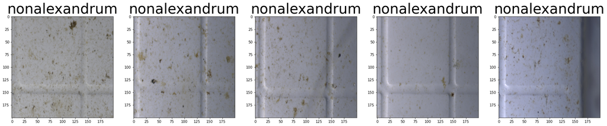

```python
import matplotlib.pyplot as plt
from PIL import Image
import os
import csv
from math import ceil

DATA_DIR = os.environ.get('LOCAL_DATA_DIR')
DATA_DOWNLOAD_DIR = os.environ.get('DATA_DOWNLOAD_DIR')
csv_path = os.path.join(DATA_DIR, 'split', 'test', 'nonalexandrum', 'result.csv')
results = []
with open(csv_path) as csv_file:
    csv_reader = csv.reader(csv_file, delimiter=',')
    for row in csv_reader:
        results.append((row[0], row[1]))

w,h = 200,200
fig = plt.figure(figsize=(30,30))
columns = 5
rows = 1
for i in range(1, columns*rows + 1):
    ax = fig.add_subplot(rows, columns,i)
    img = Image.open(results[i][0].replace(DATA_DOWNLOAD_DIR, DATA_DIR))
    img = img.resize((w,h), Image.ANTIALIAS)
    plt.imshow(img)
    ax.set_title(results[i][1], fontsize=40)
```

## 10. Export and Deploy!

```python
!tao classification export \
            -m $USER_EXPERIMENT_DIR/output_retrain/weights/resnet_$EPOCH.tlt \
            -o $USER_EXPERIMENT_DIR/export/final_model.etlt \
            -k $KEY
```

```
2021-11-28 09:48:42,718 [INFO] root: Registry: ['nvcr.io']
Matplotlib created a temporary config/cache directory at /tmp/matplotlib-rnep15gq because the default path (/.config/matplotlib) is not a writable directory; it is highly recommended to set the MPLCONFIGDIR environment variable to a writable directory, in particular to speed up the import of Matplot…
WARNING:tensorflow:Deprecation warnings have been disabled. Set TF_ENABLE_DEPRECATION_WARNINGS=1 to re-enable them.
2021-11-28 09:48:52,215 [INFO] iva.common.export.keras_exporter: Using input nodes: ['input_1']
2021-11-28 09:48:52,215 [INFO] iva.common.export.keras_exporter: Using output nodes: ['predictions/Softmax']
NOTE: UFF has been tested with TensorFlow 1.14.0.
WARNING: The version of TensorFlow installed on this system is not guaranteed to work with UFF.
DEBUG: convert reshape to flatten node
DEBUG [/usr/local/lib/python3.6/dist-packages/uff/converters/tensorflow/converter.py:96] Marking ['predictions/Softmax'] as outputs
2021-11-28 09:49:18,073 [INFO] tlt.components.docker_handler.docker_handler: Stopping container.
```

```python
print('Exported model:')
print('------------')
!ls -lh $LOCAL_EXPERIMENT_DIR/export/
```

```
Exported model:
------------
total 57M
-rw-r--r-- 1 ubuntu ubuntu 18M Nov 28 09:47 calibration.tensor
-rw-r--r-- 1 ubuntu ubuntu 39M Nov 28 09:49 final_model.etlt
```

### A. Int8 Optimization

Classification model supports int8 optimization for inference in TRT. Inorder to use this, we must calibrate the model to run 8-bit inferences. This involves 2 steps

- Generate calibration tensorfile from the training data using tlt-int8-tensorfile
- Use tao export to generate int8 calibration table.

*Note: For this example, we generate a calibration tensorfile containing 10 batches of training data. Ideally, it is best to use atleast 10-20% of the training data to calibrate the model.*

```python
!tao classification calibration_tensorfile -e $SPECS_DIR/classification_retrain_spec.cfg \
                                    -m 10 \
                                    -o $USER_EXPERIMENT_DIR/export/calibration.tensor
```

```python
# Remove the pre-existing exported .etlt file.
# !rm -rf $LOCAL_EXPERIMENT_DIR/export/final_model.etlt
!tao classification export \
            -m $USER_EXPERIMENT_DIR/output_retrain/weights/resnet_$EPOCH.tlt \
            -o $USER_EXPERIMENT_DIR/export/final_model.etlt \
            -k $KEY \
            --cal_data_file $USER_EXPERIMENT_DIR/export/calibration.tensor \
            --data_type int8 \
            --batches 10 \
            --cal_cache_file $USER_EXPERIMENT_DIR/export/final_model_int8_cache.bin \
            -v
```

### B. Generate TensorRT engine

Verify engine generation using the `tao-converter` utility included with the docker.

The `tao-converter` produces optimized tensorrt engines for the platform that it resides on. Therefore, to get maximum performance, please instantiate this docker and execute the `tao-converter` command, with the exported `.etlt` file and calibration cache (for int8 mode) on your target device. The tao-converter utility included in this docker only works for x86 devices, with discrete NVIDIA GPU's.

For the jetson devices, please download the tao-converter for jetson from the dev zone link [here](https://developer.nvidia.com/tao-converter).

If you choose to integrate your model into deepstream directly, you may do so by simply copying the exported `.etlt` file along with the calibration cache to the target device and updating the spec file that configures the `gst-nvinfer` element to point to this newly exported model. Usually this file is called `config_infer_primary.txt` for detection models and `config_infer_secondary_*.txt` for classification models.

```python
!tao converter $USER_EXPERIMENT_DIR/export/final_model.etlt \
               -k $KEY \
               -c $USER_EXPERIMENT_DIR/export/final_model_int8_cache.bin \
               -o predictions/Softmax \
               -d 3,224,224 \
               -i nchw \
               -m 64 -t int8 \
               -e $USER_EXPERIMENT_DIR/export/final_model.trt \
               -b 64
```